# Fur seal odour encodes colony membership, mother-offspring similarity, relatedness and genetic quality

Stoffel, M.A., Caspers, B.A., Forcada, J., Giannakara, A., Baier, M.C., Eberhart-Phillips, L.J. , Müller, C. & Hoffman, J.I.

!!!This file is under developement!!! and will soon contain all major analyses.

This documentation explains the main analyses from our paper and provides the accompanying code sections as well as figures. The complete code can be found [in this github repository](https://github.com/mastoffel/scent/tree/master/final_script). We wrote two small R packages for our analysis. You can directly download them from github with the devtools package:

```r
library(devtools)
# install_github("mastoffel/minmodelr")
# install_github("mastoffel/g2")
library(minmodelr)
library(g2)
```

See ?MinMod, ?DelTestVar, ?g2 for further information on the functions. We will use them thoughout this documentation.

### Loading data, standardisation and transformation

Loading the raw scent data (aligned by algorithm) and a factor data frame containing identities for colony membership (colony), mother-offspring pairs (family) and mothers and pups, respectively (age)

```r
scent_raw <- as.data.frame(t(read.csv(".\\files\\scent_raw.csv", row.names = 1)))
factors <- read.csv(".\\files\\factors.csv",row.names=1)
head(factors)
```

```
##     colony family age
## M10      2     10   1
## M12      2     12   1
## M14      2     14   1
## M15      1     15   1
## M16      2     16   1
## M17      2     17   1
```

Standardising observations by total, such that within every observation compounds add up to 100 % (Thus averaging out absolute concentration differences between samples)

```r
scent_stand <- as.data.frame(t(apply(scent_raw, 1, function(x) (x/sum(x)) * 100)))
```

Log(x+1) transformation of the standardised scent data.

```r
scent <- log(scent_stand + 1)
```

The scent matrix contains 82 observations and 213 compounds (retention times are column names) in total.

```r
dim(scent)
```

```
## [1]  82 213
```

```r
head(scent[1:6])
```

```
##     8.061111111     8.23 8.307142857 8.394  8.47375 8.516153846
## M10    0.000000 0.000000   0.0000000     0 0.000000   0.6562090
## M12    0.000000 0.000000   0.4864961     0 0.000000   0.0000000
## M14    3.222626 1.665421   0.0000000     0 0.000000   0.0000000
## M15    0.000000 0.000000   0.0000000     0 0.000000   0.0000000
## M16    0.000000 0.000000   0.6849915     0 1.008018   0.5654895
## M17    2.330450 0.000000   0.0000000     0 0.000000   0.0000000
```

### Differences in olfactory fingerprints between the two colonies

```r
library(vegan)
library(MASS)
```

**Non-metric multidimensional scaling (nMDS)** visualizes a distance matrix (Bray-Curtis similarity). The nMDS algorithm aims to place each individual in a 2-dimensional space such that the between-individual distances are preserved as well as possible. Axis coordinates are arbitrary and not shown. The plot is better visualized with colours (see paper) and is shown here for the purpose of demonstration. Mother-offspring pairs can be identified by labels (e.g. M14, P14)

```r
scent_mds <- isoMDS(vegdist(scent))
```

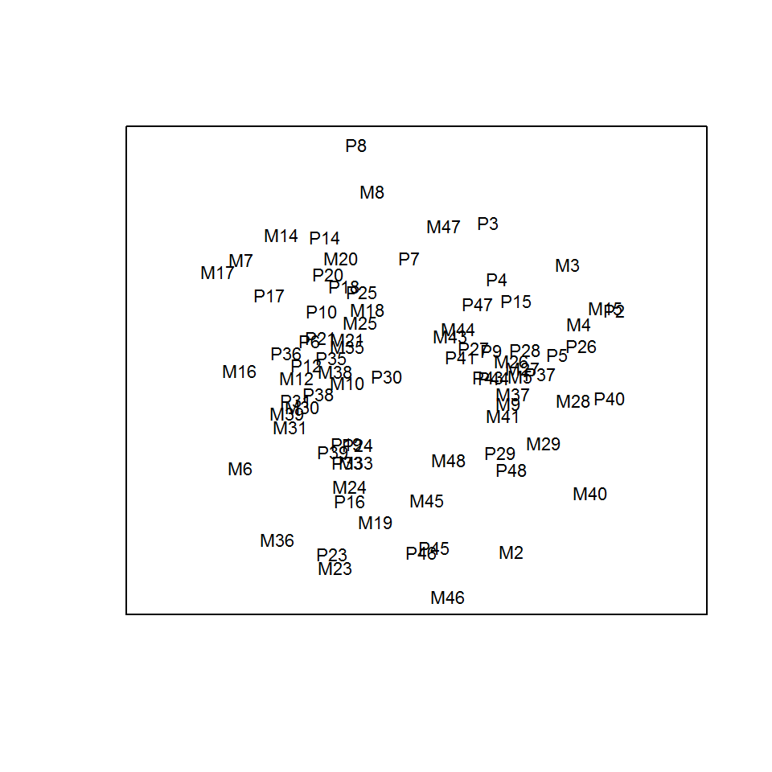

```r
ordiplot(scent_mds, type = "t", ylab = "", xlab = "",axes=FALSE, frame.plot=TRUE)
```

**Analysis of Similarities (ANOSIM)** is a distribution-free test for group differences based on a Bray-curtis similarity matrix. Here is an example which tests for a significant difference between the two colonies. ANOSIM is philosphically connected to nMDS as it also uses only the rank order of dissimilarity values.

*ANOSIM - Dissimilarity between the two colonies.*

```r
anosim(dat = scent, grouping = factors$colony,
       distance = "bray", permutations = 1000)
```

```
##
## Call:
## anosim(dat = scent, grouping = factors$colony, permutations = 1000,      distance = "bray")
## Dissimilarity: bray
##
## ANOSIM statistic R: 0.5691
##       Significance: 0.000999
##
## Based on  1000  permutations
```

- The two colonies are highly dissimilar in their olfactory fingerprints.

### Mother-offspring similarity

**ANOSIM** can also be used to test for differences between mother-offspring pairs, basically asking the question if mother-offspring pairs have their own scent “identity”. For computational reasons, the following examples use 1000 permutations while we used 10000 for the article.

**Overall**

```r
anosim(dat = scent, grouping = factors$family,
       distance = "bray", permutations = 1000)
```

```
##
## Call:
## anosim(dat = scent, grouping = factors$family, permutations = 1000,      distance = "bray")
## Dissimilarity: bray
##
## ANOSIM statistic R: 0.6723
##       Significance: 0.000999
##
## Based on  1000  permutations
```

**Within colony 1 (Special study beach)**

```r
anosim(dat = scent[factors$colony == 1, ],
       grouping = factors[factors$colony == 1, ]$family,
       distance = "bray", permutations = 1000)
```

```
##
## Call:
## anosim(dat = scent[factors$colony == 1, ], grouping = factors[factors$colony ==      1, ]$family, permutations = 1000, distance = "bray")
## Dissimilarity: bray
##
## ANOSIM statistic R: 0.5339
##       Significance: 0.000999
##
## Based on  1000  permutations
```

**Within colony 2 (Freshwater beach)**

```r
anosim(dat = scent[factors$colony == 2, ],
       grouping = factors[factors$colony == 2, ]$family,
       distance = "bray", permutations = 1000)
```

```
##
## Call:
## anosim(dat = scent[factors$colony == 2, ], grouping = factors[factors$colony ==      2, ]$family, permutations = 1000, distance = "bray")
## Dissimilarity: bray
##
## ANOSIM statistic R: 0.4532
##       Significance: 0.000999
##
## Based on  1000  permutations
```

- Mother-offspring pairs are highly similar in their olfactory fingerprints, both overall as well as within each colony.

### Olfactory similarity vs. geographic distance on special study beach

For the special study beach, exact data of the geographical positions is available. If mother-offspring similarity would just be caused by spatial proxomity, one would assume a correlation between geographic distance and olfactory similarity, which is not the case.

```r
coord  <- read.csv(".\\files\\coordinates_beach1.csv", row.names=1)
```

Converting coordinates to pairwise euclidian distance matrix

```r
dist_mat <- as.matrix(dist(coord, method = "euclidian"))
```

Constructing bray curtis similarity matrix of all individuals from beach 1

```r
scent_bc <- as.matrix(vegdist(as.matrix(scent[factors$colony == 1, ])),
                      method = "bray")
```

**Geographic distance vs. olfactory similarity in mothers**

```r
geo_mum <- dist_mat[1:20, 1:20]
scent_mum <- scent_bc[1:20, 1:20]
vegan::mantel(geo_mum, scent_mum, method = "spearman")
```

```
##
## Mantel statistic based on Spearman's rank correlation rho
##
## Call:
## vegan::mantel(xdis = geo_mum, ydis = scent_mum, method = "spearman")
##
## Mantel statistic r: 0.008091
##       Significance: 0.47
##
## Upper quantiles of permutations (null model):
##   90%   95% 97.5%   99%
## 0.204 0.262 0.319 0.372
##
## Based on 999 permutations
```

**Geographic distance vs. olfactory similarity in pups**

```r
geo_pup <- dist_mat[21:40, 21:40]
scent_pup <- scent_bc[21:40, 21:40]
vegan::mantel(geo_pup, scent_pup, method = "spearman")
```

```
##
## Mantel statistic based on Spearman's rank correlation rho
##
## Call:
## vegan::mantel(xdis = geo_pup, ydis = scent_pup, method = "spearman")
##
## Mantel statistic r: 0.06039
##       Significance: 0.311
##
## Upper quantiles of permutations (null model):
##   90%   95% 97.5%   99%
## 0.171 0.220 0.264 0.302
##
## Based on 999 permutations
```

## Relatedness and overall olfactory similarity

Due to the olfactory similarity of mothers and their pups, there is the risk of pseudoreplication for all following analyses. We thus splitted mothers and pups and analysed them seperately. As we did not find any relationship between genetic characteristics and scent profiles in pups, the following analysis will just show the analysis for mother for simplicity and readability.

1. Loading pairwise relatedness based on 41 markers

```r
relatedness <- as.matrix(read.csv(".\\files\\relatedness.csv",row.names=1))
```

2. Computing pairwise bray-curtis similarity.

```r
scent_bc <- 1-(as.matrix(vegdist(as.matrix(scent)), method = "bray"))
```

3. **Mantel test between relatedness and bray curtis similarity in mothers**

```r
vegan::mantel(relatedness[factors$age == 1, factors$age == 1],
              scent_bc[factors$age == 1, factors$age == 1],
              method = "spearman", permutation = 1000)
```

```
##
## Mantel statistic based on Spearman's rank correlation rho
##
## Call:
## vegan::mantel(xdis = relatedness[factors$age == 1, factors$age ==      1], ydis = scent_bc[factors$age == 1, factors$age == 1],      method = "spearman", permutations = 1000)
##
## Mantel statistic r: 0.05938
##       Significance: 0.096903
##
## Upper quantiles of permutations (null model):
##    90%    95%  97.5%    99%
## 0.0572 0.0770 0.0876 0.1080
##
## Based on 1000 permutations
```

- No relationship between olfactory similarity (based on the overall fingerprint) and genetic relatedness.

## Correlation between Heterozygosity and number of compounds in odour profiles

1. Loading standardised multilocus heterozygosity (sMLH) based on 41 markers

```r
heterozygosity <- as.matrix(read.csv(".\\files\\heterozygosity.csv", row.names=1))
```

2. Average number of compounds per individual

```r
num_comp <- as.vector(apply(scent, 1, function(x) length(x[x>0])))
```

3. Correlation between Heterozygosity and number of compounds in mothers

```r
het_mum <- heterozygosity[factors$age == 1]
num_comp_mum <- num_comp[factors$age==1]
summary(glm(het_mum ~ num_comp_mum))
```

```
##
## Call:
## glm(formula = het_mum ~ num_comp_mum)
##
## Deviance Residuals:
##       Min         1Q     Median         3Q        Max
## -0.199092  -0.049233   0.005578   0.047716   0.161657
##
## Coefficients:
##               Estimate Std. Error t value Pr(>|t|)
## (Intercept)  0.9339120  0.0282431  33.067   <2e-16 ***
## num_comp_mum 0.0015912  0.0006936   2.294   0.0273 *
## ---
## Signif. codes:  0 '***' 0.001 '**' 0.01 '*' 0.05 '.' 0.1 ' ' 1
##
## (Dispersion parameter for gaussian family taken to be 0.007451746)
##
##     Null deviance: 0.32984  on 40  degrees of freedom
## Residual deviance: 0.29062  on 39  degrees of freedom
## AIC: -80.569
##
## Number of Fisher Scoring iterations: 2
```

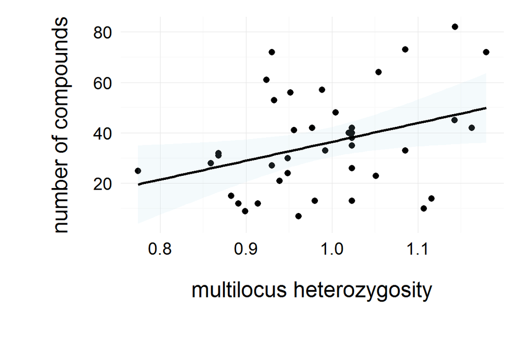

## Effect of the number of genetic markers on the correlation between heterozygosity

and olfactory fingerprint complexity

For this study, we used an unusually high number of genetic markers to reliably estimate heterozygosity and relatedness. We wanted to see how the correlation with number of compounds in a scent profile develops with heterozygosity being estimated from an increasing number of markers. A constant increase also suggests the correlation to reflect a global rather than a local effect.

1. Loading genotype data and showing the first 3 loci.

```r
library(Rhh)
genotypes <- read.table(".\\files\\genotypes.txt", row.names = 1)
head(genotypes)[1:6]
```

```
##      V2  V3  V4  V5  V6  V7
## M10 168 184 237 241 164 164
## M12 168 168 233 233 164 164
## M14 168 170 231 237 164 166
## M15 168 182 227 229 164 164
## M16 168 168 231 233 164 164
## M17 166 172 231 237 164 164
```

2. Genetic-marker resampling function.
- genotypes is the genotype data
- y is a vector containing the number of compounds the olfactory fingerprints
- num_iter specifies how often a given set of markers should be randomly sampled and correlation with heterozygosity computed
- subset_rows subsets mothers after computing heterozygosity from the entire data

```r
resample_loci <- function(genotypes, y, num_iter = 1000, subset_rows = 1:41) {
        y <- y[subset_rows]
        num_loci <- ncol(genotypes)/2
        results <- data.frame(matrix(nrow = num_iter, ncol = num_loci))
        ind <- seq(from = 1, to = ncol(genotypes) - 1, by = 2)
        for (i in seq(from = 1, to = num_loci)) {
                for (k in seq_along(1:num_iter)) {
                        loci_ind <- as.list(sample(ind, i, replace = FALSE))
                        gen_sub <- lapply(loci_ind, function(x) genotypes[x:(x+1)])
                        gen_sub <- do.call("cbind", gen_sub)
                        het <- Rhh::sh(gen_sub)[subset_rows, ]
                        results[k, i] <- cor(het,y)
                }
        }
        results
        }
```

```r
resample_mums <- resample_loci(genotypes, num_comp_mum, num_iter = 1000, subset_rows = 1:41)
```

4. Summing up the results and get mean and se for each marker number

```r
sum_results <- function(resampling_output) {
        mean.cor <- apply(resampling_output,2,mean, na.rm=T)
        sd.cor <- apply(resampling_output,2,sd, na.rm=T)
        se.cor <- sd.cor/(sqrt(sd.cor))
        sum_results <- data.frame(locnum = 1:ncol(resampling_output),
                                  cormean = mean.cor, corsd = sd.cor, corse = se.cor)
}
results_mums <- sum_results(resample_mums)
```

5. Plotting results

[figure not shown]